# Teaching co-ordinator handover

Milan Valášek

## Timeline

### Summer

- This is the time to reflect on the previous year and implement any changes to course materials and teaching process in collaborations with Course Organisers/Stats Curriculum co-ordinator.
- As MSc dissertations are due in the middle of August, there will be quite a few MSc students knocking on your door, asking you for help with `R` and stats.

### July

- About this time, you should start being mindful of next year’s schedule and room booking. These usually roll over from the previous year but it’s a good idea to check with teaching offices/timetabling if you haven’t heard from them come August.
- Recruit TAs for next year and allocate them into tutorial groups

### Late August/Early September

- Finalise all room/schedule admin
- Set up Learn pages for all stats courses
- Check that you have email addresses of all new lecturers and TAs
- Update mail groups
- Talk to COs about setting up initial tutor meetings; schedule meetings with tutors (Doodle polls are good for that)
- Make sure all COs, Lecturers, TAs *etc.* (including you and other TCs) have access to all files and Learn pages they are supposed to
  - Shared drive
  - Learn pages
  - online spreadsheets (schedule, lab roster)

### Freshers’ week

- Hold initial meetings with Teaching Assistants (tutors, TAs), Course Organisers (COs), and the Stats curriculum co-ordinator to welcome new tutors and talk them through the course structure and their role/duties (see TA’s tasks). It’s good to have separate meetings for UG and MSc courses.
- Set up lecture recording
- Send out a welcome announcement on Learn for dapR 1, RMS 1 (retired in 2019/2020), and USMR
- If lab sheets are ready, upload them on Learn
- Update your web profile (office hours!)

### Term time

- Put lab sheets on Learn as soon as they are ready so that keen students can work on them of their own initiative
- Make sure lecture slides/handouts are up on Learn at least 24 hours before lecture
- Each week upload solutions to previous week’s lab sheet
- Run the labs/tutorials
- If there are any *ad hoc* goings on that the students should know about, make sure you let them know using Learn announcements

### Teaching break (Week 6)

- Applies to both semesters
- **Before week starts**, send out announcements on Learn (on all active courses) reminding students that there will be no labs
- If there is a voluntary assignment (USMR), release it.

### Week 10

- Get feedback index cards from Avril (or resource room) and hand them out to students asking them nicely for feedback on the labs/lectures/staff. Bring a box to labs where they can drop the cards anonymously
- Type up the feedback and share with CO and Lecturers
- If there is relevant feedback for TAs gently relay it to them.
- Send out an announcement thanking students for feedback, briefly summarise the main points and let them know we hear them
- Make sure you, COs and TO all agree on coursework submission and marks release deadlines.
  - Leave 4 weeks between releasing corsework and submission deadline
  - You should be able to get the marking done and moderated in a fortnight so take that into account for return date.

### Week 11

- For 2-semester courses (dapR 1, 2, RMS 1), this happens only in semester 2.
- Release coursework on Learn after the last lab group
  - Upload Coursework Details document with information on assignment and where to find data, report formatting detials, deadline, *etc.*
- Make sure submission links are live; email undergrad/postgrad Teaching Office (TO) if they are not
- If you haven’t done so yet, subscribe to discussion forums. They will get busy with questions about coursework
- Make sure there is a marking rubric for the corsework assignment **AND** exams (this is mainly on CO but you might have to nudge them)
  - revise if needed

### Four weeks later

- Before coursework deadline, schedule marking meeting with CO and TAs
  - Pick 3 submissions of varying quality and have everyone mark them using rubric to calibrate marking
  - Compare marks and notes at the meeting and resolve any issues
- Prepare admin related to coursework marking
- Allocate marking to TAs and set them a deadline, leaving a few days before the date when the marks are returned to students for moderation

### Before return date

- Moderate all fails, 70+, and borderline submissions plus at least 2 from each mark band
- CO should write up a moderation report and send it to TO

### Before exams

- Schedule exam marking meeting with COs, lecturers, and tutors a day or two after exams. TO will need some time to process the admin around exam papers so don’t rush with the meeting too much.
- Gathering all markers in a room and powering through the papers seems to be the best way so book a suitable room (F29/30 has worked in the past) and get some biscuits.

### After exams

- TO should be in touch with you to arrange pickup of exam papers from Dugald Stewart Building (DSB) around the corner
- Mark
- Select all fails, 70+, and borderline submissions plus at least 2 from each mark band and send to CO for moderation.

### End of year

- Hold feedback meetings with TAs if needed (see Performance feedback)
- Update spread sheets (schedule spreadsheet, tutor roster)
- Update links to external files in this document if needed
  - Edit teaching_coord_handover.Rmd on the shared drive, save and, instead of knitting it in R Studio, run `teachR::make.sheet("[.. path ..]/teaching_coord_handover.Rmd", "other", toc_depth = 3)`

## Schedule

**Note for 2019/2020 - 2021/2022** – There are substantial changes planned for these years. Each ear, a dapR course gets run for the first time and an RMS course gets retired (20/21 - 21/22). This will have knock-on effects on schedules and rooms required. Stats curriculum co-ordinator should be in close contact with you about this (if it’s Tom, he definitely will be).

Unless there is a new course or something went wrong in the previous year, the schedule should just roll over automatically. Do keep an eye out on email from Timetables about room booking and schedules though.

It is good to have an up-to-date stats lectures and labs [schedule spreadsheet](https://docs.google.com/spreadsheets/d/1PpgkumKnYFsdkUJXaUtG_Y0bDUiMyinjxpbdla78klA/edit?usp=sharing) such as this one.

## Room booking

To book a room, email PPLS.SchoolSecretary@ed.ac.uk, specifying the room (or room capacity) and the required time slots (check that there are no clashes with other courses for the same students). If you are booking for a course or lab, you need to book through TO.

[Bookable rooms in 7 George Square](https://uoe.sharepoint.com/sites/hss/ppls/resource_booking/_layouts/15/start.aspx#/SitePages/7GS.aspx)

[Bookable rooms on the central campus](http://www.ed.ac.uk/student-administration/timetabling/bookable-rooms/bookable-rooms-central-area)

## Mail groups

Currently, there exists a mail group for each of the stats courses managed by the TC (you). Make sure your colleague adds you to these as “Owner”.

You should update these groups as needed by removing former tutors and adding current ones. Groups can be managed using the Office 365 [webmail](http://outlook.com/ed.ac.uk) portal. The picture below shows how to add memebers.

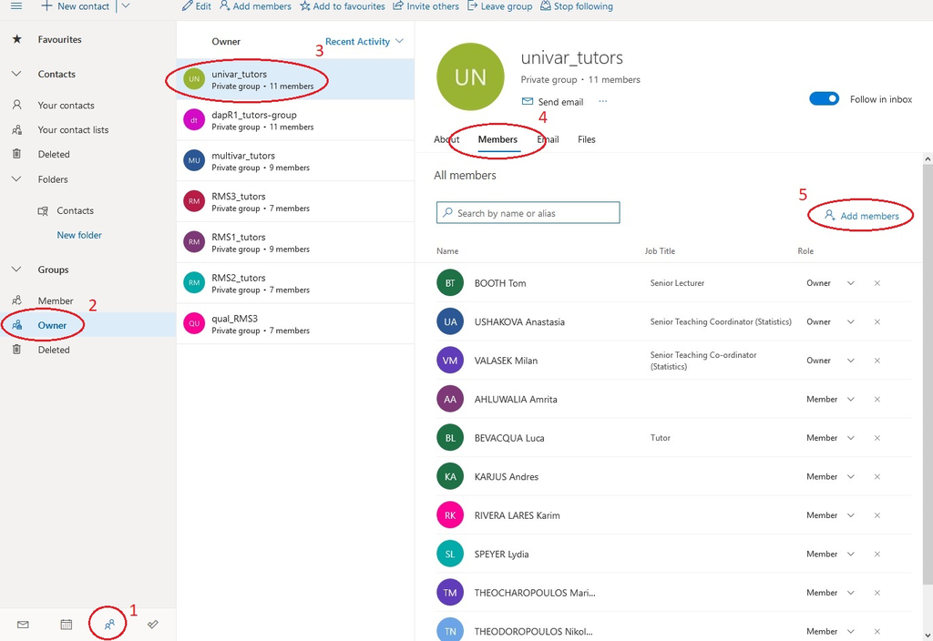

## Psychology handbooks

[Psychology handbooks](http://www.handbooks.psy.ed.ac.uk/) are the repository of information for undergraduate Psychology stdents about all courses on the programme. If contains a brief summary of each course, its lecture topics, lab structure, assessment details, and information on tourse team members and otehr useful contacts.

If up to date, it is also a very good source of information for you especially while you are still finding your feet. It does, however, need to be kept up to date.

To edit the handbooks, you need to login but in order to be able to, you need to request edi access to the handbooks from Aileen Robertson, the Web Interfaces Team Service Manager. You can [find her profile here](https://www.ed.ac.uk/information-services/computing/audio-visual-multi-media/web-development-service/who-we-are).

[figure not shown]

## Blackbroard Learn

[Blackboard Learn](https://www.learn.ed.ac.uk/) is the university’s virtual learning environment. Is may be a little counter-intuitive to work with at first but after a while it becomes positively infuriating. At some stage, you will start wondering whether someone actually got paid for it. I, for one, would certainly love to meet the person, shake their hand, and thank them for this gift that just keeps on giving. There has been rumour of a substantial overhaul so maybe things will improve soon but for now, here is the best advice I can give:

Unless there has been an issue, **copy as much as you can from last year’s Learn page for the given course**. I you don’t have access to the last year’s page, request it from UG (dapR, RMS) or PG (USMR, MSMR) Teaching Office.

In the next sections, I describe the tasks you will have to take care of. If you need more information, feel free to peruse the [university’s resources](https://www.ed.ac.uk/information-services/learning-technology/virtual-environments/learn).

### Setting up course pages

Before the start of the academic year, some time in August, the PPLS Learning Technologist (currently Natalie Chisholm) will create the Learn pages for all the courses and send out an email notification. At this point, you may or may not have access to the individual courses so, if you do not, email UG/PG Teaching office and ask them to add you, the other TCs, and Course organisers and Lecturers as instructors.

When you open a courses Learn page, you will be in edit mode by defualt. You will be able to edit any element on the page by clicking on the little v-shaped arrow that appears next to the element on hover:

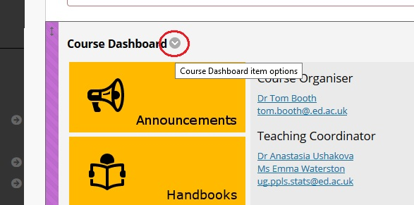

#### Add tutors

You will need to add tutors/teaching assistants on each of the corses so that they too can access the resources and monitor the discussion boards. To do that, select **Course Management** > **Users and Groups** > Users on the side panel to the left. Click on “Find Users to Enrol” and “Browse…” for a pop-up windown where you can search potential users. I suggest searching by surname. Once you have selected the people you want to add and you are back in the main “Enrol” window, **do not forget** to change their role to Instructor before clicking “Sumbit”. If you do, you can always change it by finding the person in the list of Users but it’s a bit of a pain.

Alternatively, you can email your tutors, ask them to send you their UUN (uni usernames) and enter them manually.

#### Dashboard

The dashboard is the first thing people see when they open a course page so it is good to make sure it looks and works OK. Update the details (copy from last year, if appropriate) and the links in the tiles. To do the latter, click on the tile and edit link:

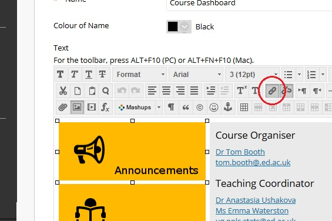

#### Forum

To create discussion forums, go to **Course Management** > **Course Tools** > Discussion Board > [Course code PSYL…] and click on “Create Forum”. It is good to have separate forums for R and R Studio, Stats, Assessment, and an additional annonymous forum. Again, you can copy previous year’s content. To make a forum annonymous, you need to tick the “Allow Anonymous Posts” box when creating/editing the forum.

Once the forums are created, it is a good idea to subscribe to them so that you get email notifications about new posts.

Finally, you want to create a link on the side panel. To do this, click on the ⊕ at the top of the panel and select “Tool link”. Pick “Discussion Board” from the “Type:” drop-down menu, give the link a name, *e.g.,* Discussion Forum and tick the “Available to Users” box (see below). You can rearrange the order of the links in the side bar but, for some otherworldly reason, it only seems to work if you’re on the main page (dashboard).

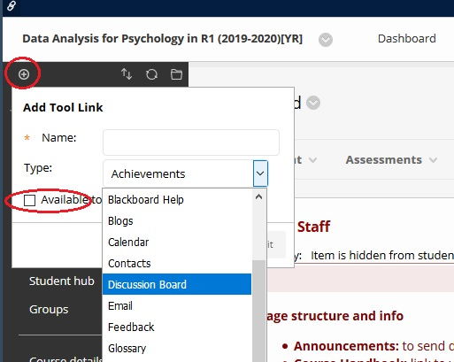

#### Details

It’s good to be able to see basic course details on the main page, just below the dashboard. At the top of the pge, click on **Build Content** and select “Item” under *Create* (because the more styles, the better!). Copy from previous year and edit as appropriate. Then, add a link to the sidebar, this time by ⊕ > Course link and specifying Location: as /Dashboard/Course details (you can use Browse…). Don’t forget to make the link available to users.

#### Content

There should already be a link to Course content (or Course materials/Lecture Notes) on the side bar and if, you’re lucky, there will already be an item per week. If there isn’t you will have to do it manually. Here is where you will upload Lecture slides and handouts, Lab sheets, and any additional material relevant for a given week. It is also good to include a “Useful tips” item at the top of the page with guides to basic installation, shortcuts, coding principles *etc* (see previous years).

**IMPORTANT:** If the course includes weekly quizzes (see Quizzes tab), you need to create a **Content Folder** for each week so that you can deploy a quiz for each week. Quizzes cannot be added to items, only folders.

#### Groups

Assigning sutents to lab groups on the UG courses is done by Teaching office and you do not have to worry about it. The only thing you might want to do is remind students that they can request a group change (info on Learn course page > Groups > Tutorial Allocation).

For the MSc course, you have to create groups for students to self-enrol to. Go to **Course Management** > **Users and Groups** > Groups and create a Self-enrol Group Set. Best thing to do is, yet again, to go to previous year’s course, click on “Edit Group Set Properties” and copy everything including which boxes to tick/untick (see below).

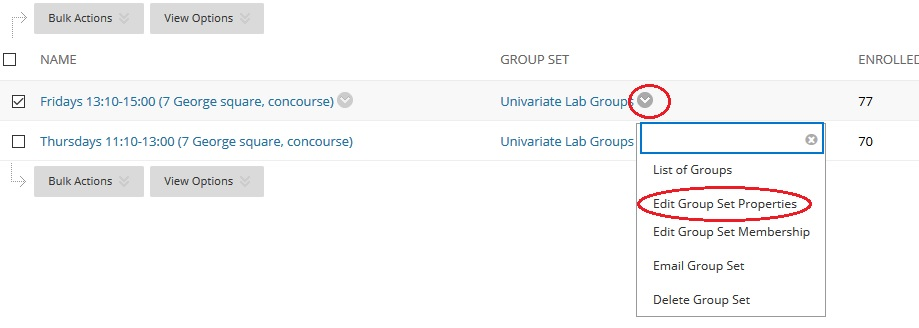

#### Assessment

Most of the content of the “Assessment details and submission” (also linked via the “Assessment” dashboard tile) will be created by Learning Technologist/Teaching office. However, you should check a few things.

First, make sure the following sections have been added and if not, contact TO:

- Link to general assessment information
- Own Work Declaration info
- Link to PPLS Writing Centre
- “How to submit assignments”
- “Important”
- “My Grades”
- “Submit Report Here”
- “Submit R Code Here”

The latter two might not be there and make sure you ask TO to create them by the time the coursework assignment has been released to students. Since these links are time sensitive, you need to double check that dates of “adaptive release” (*i.e.,* when they become available to students) correspond with releasing of the coursework and the deadlines in the description are correct.

Finally, once you are ready to release the coursework, create a Coursework Instruction item with assignment details (tasks, where to find data, submission formatting, *etc.*).

### Quizzes

UG courses feature weekly homework quizzes. Unless you are creating them from scratch, setting them up involves two tasks.

#### Migrating

First, you need to transfer the quizzes from the previous year to the current one.

1. In the source course (previous year), go to **Course Management** > **Course Tools** > Tests, surveys and pools > Tests
2. Click on the v-shaped arrow next to each deployed test and select Export to Local Computer (or Export to Content Collection and browse to the new course code - PSYL…). This has to be done one test at a time because frustration builds character, or something.
3. Once the tests are exported, go to the current year’s course to **Course Management** > **Course Tools** > Tests, surveys and pools > Tests and select Import Test > Browse My Computer/Content Collection (contingent upon step 2). Import each of the relevant tests for the course. You guessed it, one by one…

#### Deploying

Now that the tests have been migrated (or created if you’r edoing it from scratch), you can deploy them.

1. Go to Course materials (or Course content/Lecture Notes, whatever it’s called) and into the given week’s content folder.
2. Go to **Assessments** > Test and pick the appropriate test from the “Add an Existing Test” drop-down menu.
3. Set up the quiz setting according to the table below and click “Submit”.

| Option | Value |
| --- | --- |
| Change year in quiz name | Current academic year |
| Check description | Remove outdated info or references |
| Show test description to students before they begin the test | Tick |
| Check test instructions | Remove outdated info or references |
| Show instructions to students before they begin the test | Tick |
| Open test in new window | No (it can cause problems if the main window is then closed) |
| Make link available | Yes |
| Add new announcement | Maybe? Up to you… |
| Multiple attempts | No |
| Force completion | Tick |
| Set timer | Tick; Usually 60 minutes |
| Auto-submit | ON |
| Display after | Tick; Set the release date and time, usually 9 am on a Monday |
| Display until | No (so students can check their marks until the end of the year). Use the due date to set the expiration date for attempting the quiz. |
| Password | No |
| Due date | Tick; Set the due date, usually on Sunday at 5pm (released on Monday, due on Sunday) |
| Do not allow students to start test if due date has passed | Tick |
| Include this test in grade centre calculation | No for *practice* tests, handbook tests etc. Tick for statistics tests |
| Hide results for this test completely from the instructor and the Grade Centre | No |
| Show results to students | After due date (**NOT** after submission!) |
| Tick everything… | Show score, all answers, feedback, incorrect etc. |
| Test presentation | All at once |
| Prohibit backtracking and randomise questions | No (some questions might depend on previous questions results) |

4. The quiz should now appear in the content folder. Click on the v-shaped arrow to pull down the menu and select “Edit the Test”. Review the questions and response options and make sure the correct answers are actually correct.
5. While you are still on the same page, click on Question Setting and make sure the box next to “Provide feedback for individual answers.” is ticked.
6. Repeat for all weekly quizzes. :/

### Announcements

Announcements are a good way to communicate any time-sensitive news to students (*ad hoc* room changes, any errors spotted, welcome messages, calls to action *etc.*). A good place to start is to check announcements from the previous year to see what was going on and when. This will help you get a good grip on the course’s timeline.

Make sure the link in the Announcement tile is live and create a link in the side bar too.

To send out an announcement, go to the Announcements section and click on Create Announcement. Before you Submit the message, it’s worth ticking the box next to “Send a copy of this announcement immediately”. Student get email notifications of announcements and if theis option is not checked, the email will not go out until midnight (I *think*!).

### Course materials

Uploading course material is relatively straight-forward, at least by Learn’s standards. Just a few notes:

- Everything you upload into any folder/item will be uploaded to the course’s Content collection.
  - Even if you unlink a file from a folder/item, it will stay in the collection.
  - If you re-upload the file without deleting the old one from the collection, a number will get added to the name to deal with duplicate file names, *e.g.,* file_name.pfd(1).
  - You can go to the content collection and delete any files permanently.
- Create a folder with useful reference documents/links at the top of COurse materials/Lecture notes.
- For each week you should upload lecture slides, lecture notes/handouts, lab sheet and a lab sheet with answers for previous week.
  - Lectures should be uploaded at least 24 hours before the lecture according to the university policy. The lecturer can either do it themself or ask you to upload the slides and handouts for them. Sometimes, you might even have to chase them up a little, though you shouldn’t erally have to.
  - It’s good to upload lab sheets as soon as possible so that any keen beans can work ahead of schedule.
- You should create an item hidden from students, where you upload all *worked* lab sheet for the tutors ahead of the labs.

### Coursework submissions

You can find the coursework submissions form students in **Course Management** > **Course Tools** > Turnitin Assignments.

## PG tutors / TAs

### Recruitment

Tutor positions get advertised by PPLS and PhD students will apply to tutor via HR. You will likely be contacted by HR to review the job descriptions/expected hours sometime in the summer. You can ask them to add any screening questions for the stats courses but this should be discussed with Stats Curriculum Co-ordinator. Currently, there are two questions:

1. How would you explain the difference between *SD* and *SE* to a student?
2. What does the following code return and why? `x <- rnorm(100); x[ , 2]` (or something to that effect)

Once the applications are in, HR will send you a list of all applicants and their details (corse preferences, answers to screening questions, personal statements, contact details *etc.*). You will need to sift through them and decide which TAs you want to put on which course. Unless there is a very good reason, you should not deny applicants the opportunity to tutor on at least one course. This does not necessarily have to be one of your courses though, so work with the non-stats courses TCs.

If there are completely unknown quantities, you can invite them to a short informal meeting to get a feel for the level of their stats/`R`/English aptitude.

### Distributing hours

To keep things organised, it’s good to have a spread sheet such as this [Lab roster](https://docs.google.com/spreadsheets/d/13u2q99aSBBV6QWoNJsFouZuSAtrjk4ET-fwlzPO7N8A/edit?usp=sharing). There are formulae embedded in it that calculate number of hours per tutor on each course as well as in total. This should be shared with Stats Curriculum Co-ordinator an TAs.

Ultimately, there are no rules on how to allocate hours but the following tips might be useful:

- Each lab group should have at least one tutor who has totored stats in this department before, ideally on the same course
- Allocate courses according to TAs preferences as much as possible
- Aim for fairly equal distribution of hours if possible but…
- …it might be OK to give preference to senior tutors, especially the self-funded ones
- Use discussion board monitoring hours to even out big differences in allocated hours
- Try to avoid single gender tutor groups (all-male ones anyway)
- Watch out for any conflicts (one TA in two simultaneous groups)

Tutors can agree among themselves to swap groups around both for all of the course or *ad hoc*. They can also ask other tutors to cover for them if they cannot make it to their lab (with reasonable notice). If this happens, they should amend the roster spread sheet so the hours check out.

### TA’s tasks

#### Preparation

Tutors should come to labs prepared to answer questions on statistics, `R` programming, and tasks related to the current week’s lab as well as the material covered in previous weeks. They get paid for an hour of preparation per week on UG courses and two hours on MSc courses. If they tutor multiple lab groups on the same course in the same week, they only get one (two for MSc courses) prep hour a week. If the tutors need a refresher on the topic, they can come to lectures but they do not get paid for the time.

If lecturer requests that TAs be present in lectures, they should get paid for their time. Any increase in tutor hours needs to be raised with Head of Psychology in advnace.

#### Labs

Tutors should be present in the labs on time and come well prepared. They should know the solutions to all tasks in the lab sheet or carry a copy of the worked out sheet. They should be proactive in asking students how they are doing/if they have any issues with the tasks and probe student’s understanding with questions.

#### Marking

As part of their contract, the TAs are expected to be available when it is time to mark coursework and exams.

#### Claiming hours

To get paid, TAs need to claim hours using the university’s [ePay system](https://www.etime.finance.ed.ac.uk/etime/) (which you probably cannot access as this is only for staff on hourly wage).

Tutors should claim for the following:

- Tutoring in labs – one or two hours per labs for UG and MSc labs respectively
- As mentioned above, tutors get one (UG courses) or two (MSc courses) paid hours of prep for each **week** they tutor in (not each group)
- Any meetings they are resuired to attend
- Discussion board monitoring (see lab roster [spread sheet](https://docs.google.com/spreadsheets/d/13u2q99aSBBV6QWoNJsFouZuSAtrjk4ET-fwlzPO7N8A/edit?usp=sharing)) – one hour per week
- Marking
  - Exams – net time marked (within reason)
  - Coursework assignment – 0.5 hour per report

When it comes to marking, the rates are not always realistic. Since TAs have very little leverage, you might want to talk to Head of Psychology/Stats Curriculum Co-ordinator and try to find a way how to get tutors paid fairly.

#### Meetings

At the very least, there should be an initial meeting at the beginning of the year and a marking calibration meeting before submission deadline. These meetings are compulsory.

### Performance feedback

If a TA doesn’t perform their duties to an acceptable standard (often late, under-prepared, absent from labs without prior notice, *etc.*), they should be given feedback on their performance and a record should be kept of this feedback/meeting. This is important in case you want to de-select a TA from tutoring on the stats courses in the next year.

## Assessment

### Quizzes (UG courses)

### Intermittent assessment (dapR)

### Voluntary assignment (USMR)

### Coursework

#### Admin

#### Marking

### Exams (UG courses)

#### Admin

#### Marking

## Student feedback

## Useful contacts

#### Head of Psychology

[Prof Martin Corley](https://www.ed.ac.uk/profile/martin-corley) (CO for USMR)

#### Stats Curriculum Co-ordinator

[Dr Tom Booth](https://www.ed.ac.uk/profile/tom-booth) (go-to for most UG stats things)

#### Non-stats TC

[Dr Eva Murzyn](https://www.ed.ac.uk/profile/eva-murzyn)

#### UG Teaching Office

ppls.teachingoffice@ed.ac.uk

[Stephanie Fong](https://www.ed.ac.uk/profile/stephanie-fong)

[Alex MacAndrew](https://www.ed.ac.uk/profile/alex-macandrew)

#### PG Office

pplspgoffice@ed.ac.uk

[Toni Noble](https://www.ed.ac.uk/profile/toni-noble)

#### HR

ppls-hr@ed.ac.uk

[Amanda Nisbet](https://www.ed.ac.uk/profile/amanda-nisbet) – TA contracts

#### IT crowd

IS.Helpline@ed.ac.uk – General IT requests

R and R Studio on Lab computers

[Ronny Wiegand](https://www.ed.ac.uk/profile/ronny-wiegand)

[Steve Boyd](https://www.ed.ac.uk/profile/stephen-boyd)

#### Learning technologist

[Natalie Chisholm](https://www.ed.ac.uk/profile/natalie-chisholm) – Lecture recording & Learn